# Riak

```python
import riak
from pprintpp import pprint as pp
import json
import pandas as pd

import uuid
import hashlib
```

## Lectura de información en Pandas

Partimos del dataset normalizado y lo desnormalizamos para guardarlo todo junto en RIAK

```python
df_mov = pd.read_excel("./data/black.xlsx", sheet_name= "Movimientos",  engine='openpyxl')
df_miembros = pd.read_excel("./data/black.xlsx", sheet_name= "Miembros",  engine='openpyxl')
df = pd.merge(df_mov, df_miembros, on = ['id_miembro'], how = 'inner')
df.info()
```

```
<class 'pandas.core.frame.DataFrame'>
Int64Index: 7624 entries, 0 to 7623
Data columns (total 11 columns):
 #   Column              Non-Null Count  Dtype
---  ------              --------------  -----
 0   id_miembro          7624 non-null   int64
 1   fecha               7624 non-null   datetime64[ns]
 2   hora                7624 non-null   int64
 3   minuto              7624 non-null   int64
 4   importe             7624 non-null   float64
 5   comercio            6882 non-null   object
 6   actividad_completa  7621 non-null   object
 7   actividad           7621 non-null   object
 8   nombre              7624 non-null   object
 9   funcion             7624 non-null   object
 10  organizacion        6060 non-null   object
dtypes: datetime64[ns](1), float64(1), int64(3), object(6)
memory usage: 714.8+ KB
```

```python
df.head(5)
```

|  | id_miembro | fecha | hora | minuto | importe | comercio | actividad_completa | actividad | nombre | funcion | organizacion |
| --- | --- | --- | --- | --- | --- | --- | --- | --- | --- | --- | --- |
| 0 | 77 | 2006-04-17 | 11 | 40 | 44.56 | FCIA TORRES MU¬OZ | FARMACIAS | SALUD | Ricardo Romero de Tejada y Picatoste | concejal | Partido Popular |
| 1 | 77 | 2010-12-18 | 14 | 35 | 3.65 | PK VELAZQUEZ JORGE JUAN | GARAJES Y APARCAMIENTOS | COCHE | Ricardo Romero de Tejada y Picatoste | concejal | Partido Popular |
| 2 | 77 | 2009-04-06 | 11 | 56 | 1000.00 | ANTONIO HUESO | ELECTRODOMESTICOS,EQUIPOS ELECTRICOS | HOGAR | Ricardo Romero de Tejada y Picatoste | concejal | Partido Popular |
| 3 | 77 | 2007-10-19 | 10 | 49 | 102.91 | CEDIPSA 17017-1 TRUJILLO | CEPSA | COCHE | Ricardo Romero de Tejada y Picatoste | concejal | Partido Popular |
| 4 | 77 | 2010-02-11 | 16 | 48 | 68.95 | CEDIPSA 17018-1 TRUJILLO | CEPSA | COCHE | Ricardo Romero de Tejada y Picatoste | concejal | Partido Popular |

## Funciones de Utilidad

### Funcion para convertir una lista de JSON a Pandas

En la siguiente función partimos del objeto JSON que nos devuelve RIAK y generamos un DataFrame Pandas.

En el caso de la fecha, lo convertimos desde un UNIX Timestamp al formato correcto para Pandas

```python
def json_to_pandas(rows):
    # Convertimos el objeto JSON en un objeto pandas
    df = pd.read_json(json.dumps(rows))

    if 'fecha' in df.columns:
        # Las fechas están en formato UNIX TIMESTAMP. Las volvemos a convertir a formato Date...
        df = df.assign(fecha = pd.to_datetime(df.fecha, unit = 'ms'))

    return df
```

```python
values = [
    { "column1" : 1, "column2": 2 },
    { "column1" : 13, "column2": 23 }
]

json_to_pandas(values)
```

|  | column1 | column2 |
| --- | --- | --- |
| 0 | 1 | 2 |
| 1 | 13 | 23 |

### Funcion para obtener el código Hash de un String

La siguiente función convertirá un String a un código HASH que tiene la propiedad de ser siempre el mismo para un determinado String

```python
def hash_string(value):
    value_utf8 = value.encode('utf-8')
    return hashlib.md5(value_utf8).hexdigest()
```

```python
print(hash_string("Nombre Apellido"))
```

```
779955fdd274a9b63005b12a95f8c639
```

```python
print(hash_string("Nombre Apellido"))
```

```
779955fdd274a9b63005b12a95f8c639
```

```python
print(hash_string("Nombre Otro Apellido"))
```

```
21775d9ca6b4e250f0a0f6097e329f37
```

## Riak ...

```python
# connect to database
cliente = riak.RiakClient()
cliente.ping()
```

```
True
```

Utilizamos un bucket para guardar los movimientos en formato JSON y otro para guardar el importe acumulado por miembro, que nos servirá para contestar a una de las preguntas del caso de uso

En el bucket de movimientos utilizamos una clave autogenerada, ya que en el dataset no hay ningún campo que sea clavé única. Sin embargo tendremos un índice que nos permitira localizar los movimientos de una determinada persona. La clave del índice utilizaremos un código HASH debido a que un código de Riak no puede tener ni acentos ni espacios.

En el bucket con el importe acumulado la clave es el nombre de la persona en formato HASH, para no tener problemas ni con los espacios del nombre ni con los acentos. En este caso sólo hay un registro por cada persona del dataset. Utilizaremos un **mapa** en lugar de un JSON para poder utilizar la funcionalidad de de **contadores** de Riak

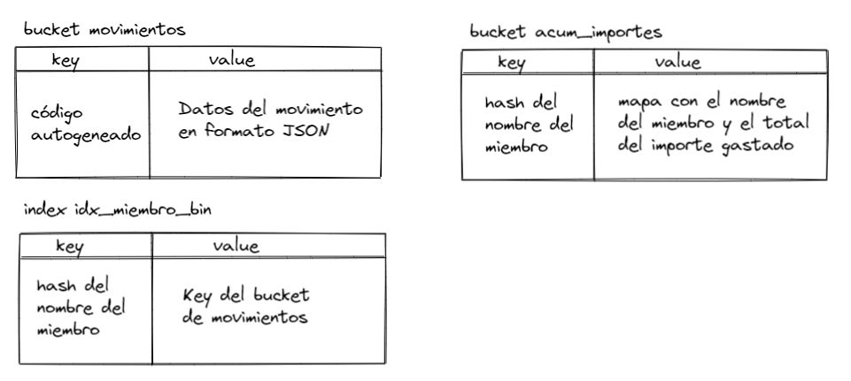

```python
BUCKET_MOVIMIENTOS = 'movimientos'
BUCKET_ACUM_IMPORTES = 'acum_importes'

bucket_mov = cliente.bucket(BUCKET_MOVIMIENTOS)
bucket_acum_importes = cliente.bucket_type('maps').bucket(BUCKET_ACUM_IMPORTES)
```

Función para eliminar los datos de un BUCKET de Riak

```python
# Se permiten operaciones de listado (No utilizar en PRODUCCION!)
riak.disable_list_exceptions = True
```

```python
def drop_keys(bucket):
    for keys in bucket.stream_keys():
        for key in keys:
            bucket.delete(key)
```

```python
# Borramos los datos ..
drop_keys(bucket_mov)
drop_keys(bucket_acum_importes)
```

```python
riak.disable_list_exceptions = False
```

## Inserción de información en Riak

Para generar los datos en formato JSON partimos del DataFrame de Pandas y lo exportamos a JSON (en formato String) para luego cargarlo en un diccionario de Python

Observa que cuando se genera el dato en formato JSON, los campos fechas se almacenan como un [TIMESTAMP de unix](http://www.unixtimestamp.com), por lo que habría que volver a convertirlo a fecha según el caso

```python
json_string = df.to_json(orient = 'records')
json_list = json.loads(json_string)
```

```python
print(len(json_list))
```

```
7624
```

```python
pp(json_list[0])
```

```
{
    'actividad': 'SALUD',
    'actividad_completa': 'FARMACIAS',
    'comercio': 'FCIA TORRES MU¬OZ',
    'fecha': 1145232000000,
    'funcion': 'concejal',
    'hora': 11,
    'id_miembro': 77,
    'importe': 44.56,
    'minuto': 40,
    'nombre': 'Ricardo Romero de Tejada y Picatoste',
    'organizacion': 'Partido Popular',
}
```

Recorremos el dataset de movimientos, almacenando la información tanto en el bucket de movimientos como en el bucket que acumula los movimientos por cliente.

En este último utilizamos una funcionalidad que nos da Riak para guardar la información tipificada. Utilizamos un mapa que tiene dos elementos: Un registro donde guardamos el nombre del cliente y un contador donde guardamos el importe sin decimales

Vamos a utilizar el nombre de la persona como clave tanto en el índice de la tabla de movimientos, como en el bucket de importes acumulados, por lo que necesitamos convertirla previamente a un código que no lleve ni espacios ni acentos. Para ello utilizaremos la función que convierte un String a un código Hash!

Como el contador no puede guardar datos decimimales, convertimos el importe a un entero multiplicando por 100. Cuando recuperemos la informacion devemos de dividir por 100 para volver a tener decimales

```python
# Bucle de carga de datos ...
for index, movimiento_json in enumerate(json_list):
    key = uuid.uuid4().hex
    hash_nombre =  hash_string(movimiento_json["nombre"])

    movimiento = bucket_mov.new(key, movimiento_json)
    movimiento.add_index('idx_miembro_bin', hash_nombre)
    movimiento.store()

    map_nombre = bucket_acum_importes.new(hash_nombre)
    map_nombre.registers['nombre'].assign(movimiento_json["nombre"])
    map_nombre.counters['importe'].increment(int(round(movimiento_json["importe"] * 100)))
    map_nombre.store()

    if index % 500 == 0:
        print(index)
```

```
0
500
1000
1500
2000
2500
3000
3500
4000
4500
5000
5500
6000
6500
7000
7500
```

Comprobamos que los datos están correctos en los 3 primeros registros

```python
riak.disable_list_exceptions = True

values = []
for key in bucket_mov.get_keys()[0:3]:
    data = bucket_mov.get(key).data
    values.append(data)

riak.disable_list_exceptions = False

json_to_pandas(values)
```

|  | id_miembro | fecha | hora | minuto | importe | comercio | actividad_completa | actividad | nombre | funcion | organizacion |
| --- | --- | --- | --- | --- | --- | --- | --- | --- | --- | --- | --- |
| 0 | 29 | 2007-08-23 | 19 | 48 | 156.25 | GIGANTE SUPERMERCADOS | HIPERMERCADOS (TECNOLOGIA ELECTRONICA) | SUPERMERCADO | Javier de Miguel Sánchez | concejal | Partido Popular |
| 1 | 73 | 2006-07-12 | 17 | 2 | 1.23 | ACESA | ACESA | COCHE | Ramón Espinar Gallego | concejal | PSOE |
| 2 | 72 | 2011-01-06 | 15 | 26 | 50.00 | None | SERV.ORG.PUBL.Y GRANDES EMPRESAS | BUSINESS | Rafael Spottorno Díaz Caro | directivo | None |

Ahora mostramos los datos del bucket con los datos acumulados ...

```python
riak.disable_list_exceptions = True

for key in bucket_acum_importes.get_keys()[0:3]:
    data = bucket_acum_importes.get(key).value
    print('%s -> %s' % (key, data))

riak.disable_list_exceptions = False
```

```
3cbc841a44235abe8646871c429d2950 -> {('importe', 'counter'): 118312, ('nombre', 'register'): 'Rafael Pradillo Moreno de la Santa'}
15b7d507a68b1b7cd3b3910920c5f126 -> {('importe', 'counter'): 2267749, ('nombre', 'register'): 'Rubén Cruz Orive'}
d51e4e145b8fb8b841381c565704890e -> {('importe', 'counter'): 3155645, ('nombre', 'register'): 'Carmen Contreras Gómez'}
```

# Lectura de información en Riak

### Lectura del bucket de movimientos

Cargamos todos los movimientos de la base de datos y lo guardamos en un objeto Pandas, ya que hay ciertas preguntas que no pueden resolverse directamente por esta base de datos

Recuerda que RIAK permite obtener información de un clave, pero no le es posible devolver la información ordenada ...

```python
rows = []
riak.disable_list_exceptions = True
for keys in bucket_mov.stream_keys():
    for key in keys:
        # print('Key %s' % key )
        rows.append(bucket_mov.get(key).data)

riak.disable_list_exceptions = False
# Convertimos el objeto json en un objeto pandas
df_movimientos = json_to_pandas(rows)
```

```python
df_movimientos.head()
```

|  | id_miembro | fecha | hora | minuto | importe | comercio | actividad_completa | actividad | nombre | funcion | organizacion |
| --- | --- | --- | --- | --- | --- | --- | --- | --- | --- | --- | --- |
| 0 | 30 | 2011-06-15 | 19 | 15 | 18.95 | JUTECO | BODYBELL JUTECO | ESTETICA | Jesús Pedroche Nieto | concejal | Partido Popular |
| 1 | 78 | 2006-05-31 | 20 | 6 | 32.00 | SANTOYO HNOS S L IZDO | GASOLINERAS | COCHE | Rodolfo Benito Valenciano | concejal | CC OO |
| 2 | 80 | 2007-10-11 | 16 | 10 | 50.15 | CAFETERIA LASO | CAFETERIAS,SNACKS | RESTAURANTE | Rubén Cruz Orive | concejal | Izquierda Unida |
| 3 | 73 | 2009-12-17 | 18 | 49 | 55.00 | ESTACION DE SERVICIO ALCA | GASOLINERAS | COCHE | Ramón Espinar Gallego | concejal | PSOE |
| 4 | 15 | 2006-10-30 | 16 | 41 | 3.79 | APARCAMIENTO MONTALBAN | GARAJES,RESTO DE APARCAMIENTOS | COCHE | Estanislao Rodríguez-Ponga Salamanca | concejal | Partido Popular |

### Los 10 movimientos mas caros

Esta consulta no la podemos contestar directamente con la Base de Datos por lo que nos apoyamos en un proceso en el cliente

```python
df_movimientos \
    .sort_values('importe', ascending=False)\
    .filter(['nombre', 'fecha', 'actividad_completa', 'importe']) \
    .head(10)
```

|  | nombre | fecha | actividad_completa | importe |
| --- | --- | --- | --- | --- |
| 5697 | Enrique de la Torre Martínez | 2007-11-28 | AGENCIAS BANCARIAS(ANTICIPO VENTANILLA) | 12000.00 |
| 1789 | Ramón Ferraz Ricarte | 2007-12-19 | AGENCIAS BANCARIAS(ANTICIPO VENTANILLA) | 9424.08 |
| 4722 | Enrique de la Torre Martínez | 2008-10-23 | AGENCIAS BANCARIAS(ANTICIPO VENTANILLA) | 9000.00 |
| 4717 | Enrique de la Torre Martínez | 2006-11-29 | AGENCIAS BANCARIAS(ANTICIPO VENTANILLA) | 8000.00 |
| 7258 | Miguel Blesa de la Parra | 2006-12-26 | EL CORTE INGLES | 6397.31 |
| 1716 | Rafael Spottorno Díaz Caro | 2007-11-30 | CONFECCION TEXTIL EN GENERAL | 6375.00 |
| 5937 | Carmen Contreras Gómez | 2006-08-13 | HOTELES 4 Y 5 ESTRELLAS,BALNEARIOS,CAMPI | 6198.02 |
| 4220 | Matías Amat Roca | 2006-08-13 | BRITISH AIRWAYS - BRITISH A | 5763.10 |
| 2263 | Juan Manuel Astorqui Portera | 2005-07-31 | AUTOM.Y MOTOCICLETAS ( VENTAS Y REPARAC) | 5403.97 |
| 1446 | Enrique de la Torre Martínez | 2004-12-06 | AGENCIAS BANCARIAS(ANTICIPO VENTANILLA) | 5390.00 |

### Los movimientos de una persona concreta

Para obtener los movimientos de una persona en concreto si podemos **utilizar el índice** que habíamos creado Ad-hoc, aunque la ordenación se realiza en Pandas

```python
rows = []
keys = bucket_mov.stream_index("idx_miembro_bin", hash_string(u"Ildefonso José Sánchez Barcoj"))
for keys in keys.results:
    for movimiento_key in keys:
        rows.append(bucket_mov.get(movimiento_key).data)

df = json_to_pandas(rows)
```

```python
df \
    .sort_values('importe', ascending=False) \
    .filter(['nombre', 'fecha', 'actividad_completa', 'importe']) \
    .head(10)
```

|  | nombre | fecha | actividad_completa | importe |
| --- | --- | --- | --- | --- |
| 170 | Ildefonso José Sánchez Barcoj | 2009-05-04 | AGENCIAS BANCARIAS(ANTICIPO VENTANILLA) | 1500.00 |
| 43 | Ildefonso José Sánchez Barcoj | 2010-07-07 | EL CORTE INGLES | 1478.07 |
| 39 | Ildefonso José Sánchez Barcoj | 2008-03-21 | HOTELES 4 Y 5 ESTRELLAS,BALNEARIOS,CAMPI | 1392.79 |
| 75 | Ildefonso José Sánchez Barcoj | 2005-10-28 | LOUIS VUITTON/LOEWE | 1375.00 |
| 103 | Ildefonso José Sánchez Barcoj | 2009-09-28 | AGENCIAS BANCARIAS(ANTICIPO VENTANILLA) | 1000.00 |
| 142 | Ildefonso José Sánchez Barcoj | 2012-03-15 | IBERIA | 940.00 |
| 242 | Ildefonso José Sánchez Barcoj | 2010-02-05 | CONFECCION TEXTIL EN GENERAL | 930.00 |
| 218 | Ildefonso José Sánchez Barcoj | 2005-12-19 | EL CORTE INGLES | 731.00 |
| 99 | Ildefonso José Sánchez Barcoj | 2009-03-20 | PARADORES NACIONALES | 708.11 |
| 133 | Ildefonso José Sánchez Barcoj | 2009-12-07 | HOTELES 4 Y 5 ESTRELLAS,BALNEARIOS,CAMPI | 672.44 |

### Las 10 personas que mas han gastado

Hemos creado un bucket especifico con información agregada para poder contestar a esta pregunta. Como la información está en un **mapa** la tenemos que convertir a JSON para poder visualizarla con Pandas

```python
rows = []
riak.disable_list_exceptions = True
for keys in bucket_acum_importes.stream_keys():
    #print(keys)
    for key in keys:
        map_nombre = bucket_acum_importes.get(key)
        rows.append({'nombre' : map_nombre.registers['nombre'].value,
                     "importe" : float(map_nombre.counters['importe'].value) / 100})

riak.disable_list_exceptions = False

# Convertimos el objeto json en un objeto pandas
df = json_to_pandas(rows)
```

Utilizamos Pandas para ordenar la información ..,

```python
df.sort_values('importe', ascending=False).head(10)
```

|  | nombre | importe |
| --- | --- | --- |
| 20 | Enrique de la Torre Martínez | 58826.28 |
| 30 | José Antonio Moral Santín | 52447.07 |
| 11 | Ramón Ferraz Ricarte | 45371.52 |
| 34 | Miguel Blesa de la Parra | 40298.84 |
| 43 | Ildefonso José Sánchez Barcoj | 39437.99 |
| 12 | Juan Manuel Astorqui Portera | 36627.89 |
| 72 | Francisco Baquero Noriega | 35256.67 |
| 49 | Matías Amat Roca | 33434.74 |
| 2 | Carmen Contreras Gómez | 31556.45 |
| 5 | Estanislao Rodríguez-Ponga Salamanca | 29350.65 |